# Notebook_Tell_Fisk_ApS

For at skabe overblik er notebook delt op i 4 overemner

- Oversigt over Tell Fisks køb af fisk (Netværksanalyse)
- Klargøring af data
- Isoler torsk sortering 4
- Udarbejdelse af forudsigelsesmodellen

Link til github hvor filerne er: https://github.com/RasmusTChristiansen/Project-TellFisk

Link til denne Colab notebook: https://colab.research.google.com/drive/1TRHY86xfoLhBmmNBPZuktim0dQYPUniF?usp=sharing

```python
import pandas as pd
import numpy as np

import keras
from matplotlib import pyplot
from sklearn.preprocessing import MinMaxScaler

import networkx as nx

!pip install -qq holoviews
!pip install -qq -U bokeh
!pip install -qq datashader
import holoviews as hv
from holoviews import opts
hv.extension('bokeh')
from bokeh.plotting import show
kwargs = dict(width=800, height=800, xaxis=None, yaxis=None)
opts.defaults(opts.Nodes(**kwargs), opts.Graph(**kwargs))

import itertools
%matplotlib inline
import matplotlib.pyplot as plt
import plotly.offline as pyoff
import plotly.graph_objs as go
from sklearn import preprocessing
from fbprophet import Prophet
from fbprophet.plot import add_changepoints_to_plot
from fbprophet.diagnostics import cross_validation
from fbprophet.diagnostics import performance_metrics
from fbprophet.plot import plot_cross_validation_metric
from scipy.stats import boxcox
from scipy.special import inv_boxcox
```

# Oversigt over Tell Fisks køb af fisk (Netværksanalyse)

Dette afsnit har fokus på en dataekslorativ tilgang, hvor Tell Fisks mest indkøbte fisketyper findes, hvilkelt danner grundlag for den videre analyse.

```python
url = 'https://raw.githubusercontent.com/RasmusTChristiansen/Project-TellFisk/main/K%C3%B8bsoversigt.csv'
df = pd.read_csv(url, sep=';', encoding = "ISO-8859-1")
df = df.dropna(subset=['Auktion'])
df.shape
```

```
(6876, 30)
```

```python
auktionsdage = df.groupby('Dato', dropna=False).sum()
auktionsdage.shape
```

```
(252, 7)
```

```python
df
```

|  | Auktion | Art | Klas. | Sort | Redskab | MSC | SeaPacked | Ks | Kilo | Slant | Ialt | Pris | Total | Område | Dato | Redskab.1 | Sælger | Sælger navn | Sælger adresse | Post nr. | By | Land | Tlf | Email | Landingsdato | Fangst start | Fangst slut | FAO | Latin | … |
| --- | --- | --- | --- | --- | --- | --- | --- | --- | --- | --- | --- | --- | --- | --- | --- | --- | --- | --- | --- | --- | --- | --- | --- | --- | --- | --- | --- | --- | --- | --- |
| 0 | Strandby | Blålange | A | 9 | NaN | FALSK | FALSK | 1 | 0 | 7 | 7.0 | 5.0 | 35.0 | NaN | 02-11-2020 | NaN | FS | Fiskernes Samlecentral | Auktionskaj 7 1. tv | 9970 | Strandby | Denmark | NaN | NaN | 02-11-2020 | NaN | NaN | BLI | Molva Dypterygia | … |
| 1 | Strandby | Jomfruhummer | E | 2 | TRAWL | SAND | FALSK | 1 | 20 | 10 | 10.0 | 50.0 | 500.0 | 27.3.AN | 02-11-2020 | OTB | FN 293 | FN 293 | NaN | NaN | NaN | Denmark | NaN | NaN | 02-11-2020 | 30-10-2020 | 30-10-2020 | NEP | Nephrobs Norvegicus | … |
| 2 | Strandby | Jomfruhummer | E | 2 | TRAWL | SAND | FALSK | 3 | 20 | 0 | 60.0 | 67.0 | 3990.0 | 27.3.AN | 02-11-2020 | OTB | FN 220 | FN 220 | NaN | NaN | NaN | Denmark | NaN | NaN | 02-11-2020 | 30-10-2020 | 01-11-2020 | NEP | Nephrobs Norvegicus | … |
| 3 | Strandby | Krabbeklør | A | 2 | NaN | FALSK | FALSK | 1 | 25 | 0 | 25.0 | 41.0 | 1013.0 | NaN | 02-11-2020 | NaN | FS | Fiskernes Samlecentral | Auktionskaj 7 1. tv | 9970 | Strandby | Denmark | NaN | NaN | 02-11-2020 | NaN | NaN | CRE | Cancer pagurus | … |
| 4 | Strandby | Krabbeklør | A | 2 | NaN | FALSK | FALSK | 2 | 25 | 0 | 50.0 | 42.0 | 2100.0 | NaN | 02-11-2020 | NaN | FS | Fiskernes Samlecentral | Auktionskaj 7 1. tv | 9970 | Strandby | Denmark | NaN | NaN | 02-11-2020 | NaN | NaN | CRE | Cancer pagurus | … |
| ... | ... | ... | ... | ... | ... | ... | ... | ... | ... | ... | ... | ... | ... | ... | ... | ... | ... | ... | ... | ... | ... | ... | ... | ... | ... | ... | ... | ... | ... | … |
| 6871 | Strandby | Torsk | E | 2 | NaN | FALSK | FALSK | 1 | 25 | 30 | 30.0 | 48.0 | 1440.0 | NaN | 16-10-2020 | NaN | FS | Fiskernes Samlecentral | Auktionskaj 7 1. tv | 9970 | Strandby | Denmark | NaN | NaN | 16-10-2020 | NaN | NaN | COD | Gadus Morhua | … |
| 6872 | Hanstholm | Torsk | E | 4 | TRAWL | FALSK | SAND | 5 | 19 | 7 | 83.0 | 35.0 | 2864.0 | 27.4.A | 16-10-2020 | OTB | HM 227 | HM 227 "Myggenes" | Lynge Fiskeri Aps. MC Revision\r\nHavnegade 26,2 | 7680 | Thyborøn | Denmark | NaN | NaN | 16-10-2020 | 09-10-2020 | 15-10-2020 | COD | Gadus Morhua | … |
| 6873 | Strandby | Torsk | E | 4 | NaN | FALSK | FALSK | 1 | 25 | 29 | 29.0 | 35.0 | 1001.0 | NaN | 16-10-2020 | NaN | FS | Fiskernes Samlecentral | Auktionskaj 7 1. tv | 9970 | Strandby | Denmark | NaN | NaN | 16-10-2020 | NaN | NaN | COD | Gadus Morhua | … |
| 6874 | Skagen | Torsk | E | 4 | TRAWL | FALSK | FALSK | 1 | 0 | 16 | 16.0 | 28.0 | 448.0 | 27. 3AN | 16-10-2020 | OTB | S 226 | S 226 " Emmely Pilegaard" | Sct. Laurentii Vej 39 | 9990 | Skagen | Denmark | 22821284 | NaN | 16-10-2020 | 13-10-2020 | 15-10-2020 | COD | Gadus Morhua | … |
| 6875 | Skagen | Torsk | E | 4 | TRAWL | FALSK | FALSK | 2 | 25 | 26 | 51.0 | 33.0 | 1658.0 | 27. 3A | 16-10-2020 | OTB | 8542 | Skagen Samlecentral | Auktionsvej | 9990 | Skagen | Denmark | NaN | NaN | 16-10-2020 | NaN | NaN | COD | Gadus Morhua | … |

6876 rows × 30 columns

```python
network = df[['Art', 'Sort', 'Total']]
network.columns = ['Art', 'Sort', 'Total_pris']
network["Fisk+Sort"] = network["Art"].astype(str) + network["Sort"].astype(str)
network = network.assign(target=(network['Fisk+Sort']).astype('category').cat.codes)
network['source'] = 128
```

```python
network['Fisk+Sort'].nunique()
```

```
128
```

```python
total = network[['Total_pris', 'target']]
total = total.groupby('target')['Total_pris'].sum().reset_index()
```

```python
fisk = network[['target', 'Fisk+Sort']]
fisk = fisk.groupby(['Fisk+Sort']).mean().reset_index()
```

```python
edges = network[['source', 'target']]
edges = edges.groupby(['source','target']).size().reset_index()
edges.rename({0:'Antal_køb'}, axis=1, inplace=True)
edges.sort_values('Antal_køb', ascending=False)
```

|  | source | target | Antal_køb |
| --- | --- | --- | --- |
| 121 | 128 | 121 | 584 |
| 46 | 128 | 46 | 428 |
| 94 | 128 | 94 | 379 |
| 119 | 128 | 119 | 363 |
| 93 | 128 | 93 | 360 |
| ... | ... | ... | ... |
| 108 | 128 | 108 | 1 |
| 1 | 128 | 1 | 1 |
| 69 | 128 | 69 | 1 |
| 70 | 128 | 70 | 1 |
| 110 | 128 | 110 | 1 |

128 rows × 3 columns

```python
edges = edges.merge(total, how='inner', on='target')
edges = edges.merge(fisk, how='inner', on='target')
edges = edges.round(0)
edges.sort_values('Antal_køb', ascending=False)
```

|  | source | target | Antal_køb | Total_pris | Fisk+Sort |
| --- | --- | --- | --- | --- | --- |
| 121 | 128 | 121 | 584 | 1353302.0 | Torsk4 |
| 46 | 128 | 46 | 428 | 782880.0 | Kuller1 |
| 94 | 128 | 94 | 379 | 1123301.0 | Rødspætte3 |
| 119 | 128 | 119 | 363 | 655304.0 | Torsk2 |
| 93 | 128 | 93 | 360 | 717069.0 | Rødspætte2 |
| ... | ... | ... | ... | ... | ... |
| 108 | 128 | 108 | 1 | 2970.0 | Slethvarre1 |
| 1 | 128 | 1 | 1 | 274.0 | Alm Hummer9 |
| 69 | 128 | 69 | 1 | 63.0 | Multe9 |
| 70 | 128 | 70 | 1 | 88.0 | Mørksej1 |
| 110 | 128 | 110 | 1 | 4982.0 | Slethvarre3 |

128 rows × 5 columns

```python
new_row = {'source':128, 'target':128}
edges = edges.append(new_row, ignore_index=True)
```

```python
note_attr = edges.set_index('target').to_dict('index')
edgelist = list(zip(edges.source, edges.target, edges.Antal_køb))

g = nx.Graph()
degree_dict = dict(g.degree(g.nodes()))

g.add_weighted_edges_from(edgelist)
nx.set_node_attributes(g, note_attr)
g.nodes(data=True)
```

```
NodeDataView({128.0: {'source': 128.0, 'Antal_køb': nan, 'Total_pris': nan, 'Fisk+Sort': nan}, 0.0: {'source': 128.0, 'Antal_køb': 3.0, 'Total_pris': 3620.0, 'Fisk+Sort': 'Alm Hummer1'}, 1.0: {'source': 128.0, 'Antal_køb': 1.0, 'Total_pris': 274.0, 'Fisk+Sort': 'Alm Hummer9'}, 2.0: {'source': 128.0,…
```

Simpelt netværk er lavet med Networkxs draw funktion.

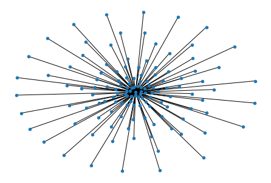

```python
nx.draw(g, with_labels = False, node_size=20)
```

Det interaktive netværk er lavet med holoview værktøjet som er blevet introduceret i undervisningen.

```python
g_layout = nx.spring_layout(g,k=0.80,iterations=30)

g_plot = hv.Graph.from_networkx(g, g_layout).opts(tools=['hover'], width=1500, edge_alpha=0.15)
labels = hv.Labels(g_plot.nodes, ['x', 'y'], 'Fisk+Sort')
from holoviews.operation.datashader import datashade, bundle_graph
bundled = bundle_graph(g_plot)

show(hv.render(bundled*labels.opts(text_font_size='10pt', text_color='black',  bgcolor='lightgray')))
```

[interactive chart not shown]

```python
edges = edges.groupby(by=["Fisk+Sort"]).sum()
edges = edges.sort_values(['Total_pris'], ascending=False)
edges['procent'] = (edges['Total_pris'] / edges['Total_pris'].sum()) * 100
edges = edges[['Antal_køb', 'Total_pris', 'procent']]
edges = edges.round(2)
print(edges.head(10))
total = edges['Total_pris'].sum()
print()
print('Total købssum', total, 'kroner')
```

```
               Antal_køb  Total_pris  procent
Fisk+Sort
Torsk4             584.0   1353302.0    10.75
Skærising2         313.0   1134111.0     9.01
Rødspætte3         379.0   1123301.0     8.92
Kuller1            428.0    782880.0     6.22
Rødspætte2         360.0    717069.0     5.70
Jomfruhummer2      284.0    671682.0     5.33
Torsk2             363.0    655304.0     5.20
Kulmule2           180.0    552752.0     4.39
Torsk3             242.0    542026.0     4.31
Lyssej3            274.0    526844.0     4.18

Total købssum 12590363.0 kroner
```

## Klargør auktionsdata

Afsnittet vil have fokus på to forskellige datasæt, som begge kan findes på github som er linket til øverst i notebooken. Først er der Fiskeauktion.dk og derefter klargøres datasættet for Danske fiskeauktioner.

# [Fiskeauktion.dk](https://fiskeauktion.dk)

```python
url = 'https://raw.githubusercontent.com/RasmusTChristiansen/Project-TellFisk/main/December2019-December2020.csv'
df_FA = pd.read_csv(url, sep=';', index_col=0)
```

```python
df_FA.isnull().sum()
```

```
Auktion      368
Art        26356
Sort       16374
Kilo       16366
Gnsn.      28354
Max.       28354
Valuta     28463
Dato         361
dtype: int64
```

```python
df_FA = df_FA.dropna()
```

Eftersom dette datasæt indeholde mange blanke linjer, anvendes nedenstående kode til kun at beholde linjer hvor valutaen er sat til DKK. Dermed fjernes disse linjer. Herefter fjernes linjer som optræder flere gange så de kun optræder 1 gange.

```python
df_FA = df_FA[df_FA['Valuta'] == 'DKK']
```

```python
df_FA.info()
```

```
<class 'pandas.core.frame.DataFrame'>
Index: 362407 entries, 8 to 255
Data columns (total 8 columns):
 #   Column   Non-Null Count   Dtype
---  ------   --------------   -----
 0   Auktion  362407 non-null  object
 1   Art      362407 non-null  object
 2   Sort     362407 non-null  object
 3   Kilo     362407 non-null  object
 4   Gnsn.    362407 non-null  object
 5   Max.     362407 non-null  object
 6   Valuta   362407 non-null  object
 7   Dato     362407 non-null  object
dtypes: object(8)
memory usage: 24.9+ MB
```

```python
df_FA = df_FA.drop_duplicates()
df_FA.shape
```

```
(45341, 8)
```

```python
df_FA.info()
```

```
<class 'pandas.core.frame.DataFrame'>
Index: 45341 entries, 8 to 255
Data columns (total 8 columns):
 #   Column   Non-Null Count  Dtype
---  ------   --------------  -----
 0   Auktion  45341 non-null  object
 1   Art      45341 non-null  object
 2   Sort     45341 non-null  object
 3   Kilo     45341 non-null  object
 4   Gnsn.    45341 non-null  object
 5   Max.     45341 non-null  object
 6   Valuta   45341 non-null  object
 7   Dato     45341 non-null  object
dtypes: object(8)
memory usage: 3.1+ MB
```

```python
df_FA = df_FA.astype({'Kilo': 'int64', 'Gnsn.': 'int64', 'Max.': 'int64'})
```

På grund af en dataudtrækningsfejl er der ikke indlæst talseperatorkommaer fra datasættet. Dette gør at alle tal skal divideres med 100, således at tallene stemmer overens med de reelle tal.

```python
df_FA['Kilo'] = df_FA['Kilo'].div(100)
df_FA['Gnsn.'] = df_FA['Gnsn.'].div(100)
df_FA['Max.'] = df_FA['Max.'].div(100)
```

```python
df_FA = df_FA.reset_index(drop=True)
```

```python
df_FA
```

|  | Auktion | Art | Sort | Kilo | Gnsn. | Max. | Valuta | Dato |
| --- | --- | --- | --- | --- | --- | --- | --- | --- |
| 0 | Hanstholm | Blæksprutte | - | 737.5 | 31.86 | 60.00 | DKK | 09-12-2019 |
| 1 | Hanstholm | Brosme | - | 408.5 | 13.60 | 19.00 | DKK | 09-12-2019 |
| 2 | Hanstholm | Glashvarre | - | 365.0 | 17.72 | 24.00 | DKK | 09-12-2019 |
| 3 | Hanstholm | Havkat | 1 | 52.0 | 44.77 | 60.00 | DKK | 09-12-2019 |
| 4 | Hanstholm | Havkat | 2 | 21.0 | 42.38 | 60.00 | DKK | 09-12-2019 |
| ... | ... | ... | ... | ... | ... | ... | ... | ... |
| 45336 | Skagen | Torsk | 1 | 35.0 | 39.11 | 43.00 | DKK | 07-12-2020 |
| 45337 | Skagen | Torsk | 2 | 71.0 | 45.77 | 47.50 | DKK | 07-12-2020 |
| 45338 | Skagen | Torsk | 3 | 236.0 | 39.29 | 39.75 | DKK | 07-12-2020 |
| 45339 | Skagen | Torsk | 4 | 140.0 | 31.82 | 34.00 | DKK | 07-12-2020 |
| 45340 | Skagen | Torsk | 5 | 473.0 | 14.40 | 18.50 | DKK | 07-12-2020 |

45341 rows × 8 columns

```python
df_FA['Sort'] = df_FA.Sort[df_FA['Sort'] != '-']
df_FA= df_FA.dropna()
```

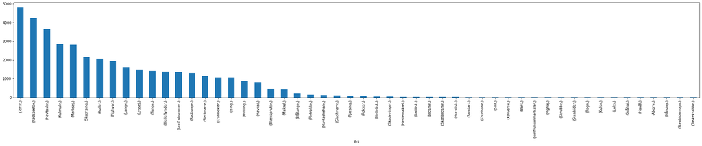

```python
art = df_FA[['Art']]
art.value_counts().plot(kind='bar', figsize=(35,5))
```

## [Danskefiskeauktioner.dk](https://dfa.as)

```python
url = 'https://raw.githubusercontent.com/RasmusTChristiansen/Project-TellFisk/main/Data_merged.csv'
```

```python
df_DFA = pd.read_csv(url, sep=';', encoding = "ISO-8859-1")
df_DFA = df_DFA.drop(['Source.Name'], axis=1)
```

```python
df_DFA
```

|  | Art | Sort | Kg. | Gnms. pris | Max | dato | auktion |
| --- | --- | --- | --- | --- | --- | --- | --- |
| 0 | Aborre | 9 | 39 | 25,30 | 25,30 | 01-04-2019 | HvideSande |
| 1 | Blæksprutter | 9 | 2 | 29,10 | 29,10 | 01-04-2019 | HvideSande |
| 2 | Brasen | 9 | 10 | 2,48 | 2,48 | 01-04-2019 | HvideSande |
| 3 | Fjæsing | 9 | 3 | 59,10 | 59,10 | 01-04-2019 | HvideSande |
| 4 | Gedde | 9 | 326 | 18,02 | 18,10 | 01-04-2019 | HvideSande |
| ... | ... | ... | ... | ... | ... | ... | ... |
| 69693 | Torsk | 2 | 1495 | 49,09 | 57,68 | 30-09-2019 | Thyborøn |
| 69694 | Torsk | 3 | 1812 | 40,56 | 47,05 | 30-09-2019 | Thyborøn |
| 69695 | Torsk | 4 | 899 | 31,48 | 34,69 | 30-09-2019 | Thyborøn |
| 69696 | Torsk | 5 | 269 | 23,86 | 24,57 | 30-09-2019 | Thyborøn |
| 69697 | Tunger | 9 | 8 | 102,63 | 104,90 | 30-09-2019 | Thyborøn |

69698 rows × 7 columns

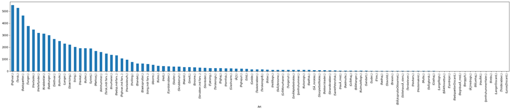

```python
art = df_DFA[['Art']]
art.value_counts().plot(kind='bar', figsize=(35,5))
```

```python
df_DFA = df_DFA[['auktion', 'Art', 'Sort', 'Kg.', 'Gnms. pris', 'Max', 'dato']]
df_DFA = df_DFA.rename(columns={"auktion": "Auktion", "Kg.": "Kilo", 'Gnms. pris': 'Gnsn.', 'Max':'Max.', 'dato':'Dato'})
```

```python
df_DFA.info()
```

```
<class 'pandas.core.frame.DataFrame'>
RangeIndex: 69698 entries, 0 to 69697
Data columns (total 7 columns):
 #   Column   Non-Null Count  Dtype
---  ------   --------------  -----
 0   Auktion  69698 non-null  object
 1   Art      69698 non-null  object
 2   Sort     69698 non-null  int64
 3   Kilo     69698 non-null  int64
 4   Gnsn.    69698 non-null  object
 5   Max.     69698 non-null  object
 6   Dato     69698 non-null  object
dtypes: int64(2), object(5)
memory usage: 3.7+ MB
```

```python
df_FA.info()
```

```
<class 'pandas.core.frame.DataFrame'>
Int64Index: 39960 entries, 3 to 45340
Data columns (total 8 columns):
 #   Column   Non-Null Count  Dtype
---  ------   --------------  -----
 0   Auktion  39960 non-null  object
 1   Art      39960 non-null  object
 2   Sort     39960 non-null  object
 3   Kilo     39960 non-null  float64
 4   Gnsn.    39960 non-null  float64
 5   Max.     39960 non-null  float64
 6   Valuta   39960 non-null  object
 7   Dato     39960 non-null  object
dtypes: float64(3), object(5)
memory usage: 2.7+ MB
```

```python
df_DFA['Gnsn.'] = df_DFA['Gnsn.'].replace(',','.', regex=True)
df_DFA['Max.'] = df_DFA['Max.'].replace(',','.', regex=True)
```

```python
df_DFA["Sort"] = pd.to_numeric(df_DFA["Sort"], downcast="float")
df_DFA["Kilo"] = pd.to_numeric(df_DFA["Kilo"], downcast="float")
df_DFA["Gnsn."] = pd.to_numeric(df_DFA["Gnsn."], downcast="float")
df_DFA["Max."] = pd.to_numeric(df_DFA["Max."], downcast="float")
df_FA["Sort"] = pd.to_numeric(df_FA["Sort"], downcast="float")
```

```python
merged = pd.concat([df_DFA, df_FA], ignore_index=True)
merged = merged.drop(['Valuta'], axis=1)
```

```python
merged
```

|  | Auktion | Art | Sort | Kilo | Gnsn. | Max. | Dato |
| --- | --- | --- | --- | --- | --- | --- | --- |
| 0 | HvideSande | Aborre | 9.0 | 39.0 | 25.299999 | 25.299999 | 01-04-2019 |
| 1 | HvideSande | Blæksprutter | 9.0 | 2.0 | 29.100000 | 29.100000 | 01-04-2019 |
| 2 | HvideSande | Brasen | 9.0 | 10.0 | 2.480000 | 2.480000 | 01-04-2019 |
| 3 | HvideSande | Fjæsing | 9.0 | 3.0 | 59.099998 | 59.099998 | 01-04-2019 |
| 4 | HvideSande | Gedde | 9.0 | 326.0 | 18.020000 | 18.100000 | 01-04-2019 |
| ... | ... | ... | ... | ... | ... | ... | ... |
| 109653 | Skagen | Torsk | 1.0 | 35.0 | 39.110000 | 43.000000 | 07-12-2020 |
| 109654 | Skagen | Torsk | 2.0 | 71.0 | 45.770000 | 47.500000 | 07-12-2020 |
| 109655 | Skagen | Torsk | 3.0 | 236.0 | 39.290000 | 39.750000 | 07-12-2020 |
| 109656 | Skagen | Torsk | 4.0 | 140.0 | 31.820000 | 34.000000 | 07-12-2020 |
| 109657 | Skagen | Torsk | 5.0 | 473.0 | 14.400000 | 18.500000 | 07-12-2020 |

109658 rows × 7 columns

```python
merged.isnull().sum()
```

```
Auktion    0
Art        0
Sort       0
Kilo       0
Gnsn.      0
Max.       0
Dato       0
dtype: int64
```

## Isoler Torsk sortering 4

Eftersom afsnit 1 konkluderer at Torsk i sortering 4 er den mest købte fisk af Tell Fisk anvendes denne i den videre analyse. Derfor isoleres denne fra de andre fisketyper.

```python
df = merged.copy()
```

```python
df
```

|  | Auktion | Art | Sort | Kilo | Gnsn. | Max. | Dato |
| --- | --- | --- | --- | --- | --- | --- | --- |
| 0 | HvideSande | Aborre | 9.0 | 39.0 | 25.299999 | 25.299999 | 01-04-2019 |
| 1 | HvideSande | Blæksprutter | 9.0 | 2.0 | 29.100000 | 29.100000 | 01-04-2019 |
| 2 | HvideSande | Brasen | 9.0 | 10.0 | 2.480000 | 2.480000 | 01-04-2019 |
| 3 | HvideSande | Fjæsing | 9.0 | 3.0 | 59.099998 | 59.099998 | 01-04-2019 |
| 4 | HvideSande | Gedde | 9.0 | 326.0 | 18.020000 | 18.100000 | 01-04-2019 |
| ... | ... | ... | ... | ... | ... | ... | ... |
| 109653 | Skagen | Torsk | 1.0 | 35.0 | 39.110000 | 43.000000 | 07-12-2020 |
| 109654 | Skagen | Torsk | 2.0 | 71.0 | 45.770000 | 47.500000 | 07-12-2020 |
| 109655 | Skagen | Torsk | 3.0 | 236.0 | 39.290000 | 39.750000 | 07-12-2020 |
| 109656 | Skagen | Torsk | 4.0 | 140.0 | 31.820000 | 34.000000 | 07-12-2020 |
| 109657 | Skagen | Torsk | 5.0 | 473.0 | 14.400000 | 18.500000 | 07-12-2020 |

109658 rows × 7 columns

```python
df_torsk4 = df.copy()
df_torsk4['Art'] = df_torsk4.Art[df_torsk4['Art'] == 'Torsk']
df_torsk4['Sort'] = df_torsk4.Sort[df_torsk4['Sort'] == 4]
df_torsk4= df_torsk4.dropna()
df_torsk4 = df_torsk4.groupby(['Dato'], as_index=False).mean()
df_torsk4.shape
```

```
(487, 5)
```

```python
df['Art'] = df.Art[df['Art'] == 'Torsk']
df['Sort'] = df.Sort[df['Sort'] == 4]
df= df.dropna()
```

```python
df
```

|  | Auktion | Art | Sort | Kilo | Gnsn. | Max. | Dato |
| --- | --- | --- | --- | --- | --- | --- | --- |
| 62 | HvideSande | Torsk | 4.0 | 14.0 | 26.900000 | 26.900000 | 01-04-2019 |
| 128 | HvideSande | Torsk | 4.0 | 20.0 | 33.700001 | 33.700001 | 02-04-2019 |
| 209 | HvideSande | Torsk | 4.0 | 1013.0 | 29.580000 | 29.940001 | 03-04-2019 |
| 244 | HvideSande | Torsk | 4.0 | 8.0 | 29.100000 | 29.100000 | 04-04-2019 |
| 317 | HvideSande | Torsk | 4.0 | 21.0 | 25.320000 | 27.799999 | 05-04-2019 |
| ... | ... | ... | ... | ... | ... | ... | ... |
| 109458 | Skagen | Torsk | 4.0 | 16.0 | 16.880000 | 20.000000 | 04-12-2020 |
| 109518 | Hanstholm | Torsk | 4.0 | 2676.0 | 34.310000 | 40.000000 | 07-12-2020 |
| 109579 | Hirtshals | Torsk | 4.0 | 879.0 | 32.160000 | 34.250000 | 07-12-2020 |
| 109618 | Strandby | Torsk | 4.0 | 321.0 | 34.180000 | 34.500000 | 07-12-2020 |
| 109656 | Skagen | Torsk | 4.0 | 140.0 | 31.820000 | 34.000000 | 07-12-2020 |

1902 rows × 7 columns

```python
df['Dato'] = pd.to_datetime(df['Dato'])
```

```python
df
```

|  | Auktion | Art | Sort | Kilo | Gnsn. | Max. | Dato |
| --- | --- | --- | --- | --- | --- | --- | --- |
| 62 | HvideSande | Torsk | 4.0 | 14.0 | 26.900000 | 26.900000 | 2019-01-04 |
| 128 | HvideSande | Torsk | 4.0 | 20.0 | 33.700001 | 33.700001 | 2019-02-04 |
| 209 | HvideSande | Torsk | 4.0 | 1013.0 | 29.580000 | 29.940001 | 2019-03-04 |
| 244 | HvideSande | Torsk | 4.0 | 8.0 | 29.100000 | 29.100000 | 2019-04-04 |
| 317 | HvideSande | Torsk | 4.0 | 21.0 | 25.320000 | 27.799999 | 2019-05-04 |
| ... | ... | ... | ... | ... | ... | ... | ... |
| 109458 | Skagen | Torsk | 4.0 | 16.0 | 16.880000 | 20.000000 | 2020-04-12 |
| 109518 | Hanstholm | Torsk | 4.0 | 2676.0 | 34.310000 | 40.000000 | 2020-07-12 |
| 109579 | Hirtshals | Torsk | 4.0 | 879.0 | 32.160000 | 34.250000 | 2020-07-12 |
| 109618 | Strandby | Torsk | 4.0 | 321.0 | 34.180000 | 34.500000 | 2020-07-12 |
| 109656 | Skagen | Torsk | 4.0 | 140.0 | 31.820000 | 34.000000 | 2020-07-12 |

1902 rows × 7 columns

```python
df = df.drop(['Art', 'Sort', 'Auktion', 'Max.'], axis=1)
```

```python
df = df.groupby(['Dato'], as_index=False).mean()
```

```python
df = df.sort_index()
```

```python
df = df.round(2)
df
```

|  | Dato | Kilo | Gnsn. |
| --- | --- | --- | --- |
| 0 | 2019-01-02 | 439.00 | 29.17 |
| 1 | 2019-01-03 | 502.33 | 27.90 |
| 2 | 2019-01-04 | 1040.33 | 29.21 |
| 3 | 2019-01-05 | 729.00 | 20.97 |
| 4 | 2019-01-07 | 3736.00 | 25.42 |
| ... | ... | ... | ... |
| 482 | 2020-12-14 | 141.00 | 21.48 |
| 483 | 2020-12-15 | 1411.00 | 20.65 |
| 484 | 2020-12-16 | 1281.00 | 25.87 |
| 485 | 2020-12-17 | 316.00 | 34.48 |
| 486 | 2020-12-18 | 1570.50 | 34.07 |

487 rows × 3 columns

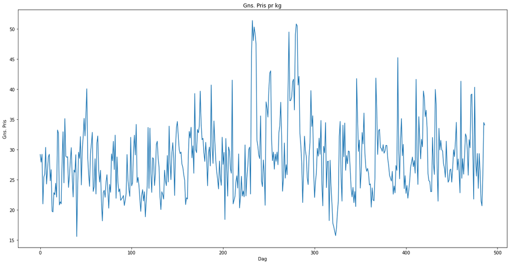

```python
plt.figure(figsize = (20,10))
plt.plot(df['Gnsn.'])
plt.title('Gns. Pris pr kg')
plt.xlabel ('Dag')
plt.ylabel ('Gns. Pris')
plt.show()
```

```python
df['Gnsn.'].sort_values()
```

```
40     15.56
323    15.71
322    16.41
324    17.07
321    17.18
       ...
272    49.50
234    50.33
281    50.53
280    50.83
232    51.41
Name: Gnsn., Length: 487, dtype: float64
```

```python
df
```

|  | Dato | Kilo | Gnsn. |
| --- | --- | --- | --- |
| 0 | 2019-01-02 | 439.00 | 29.17 |
| 1 | 2019-01-03 | 502.33 | 27.90 |
| 2 | 2019-01-04 | 1040.33 | 29.21 |
| 3 | 2019-01-05 | 729.00 | 20.97 |
| 4 | 2019-01-07 | 3736.00 | 25.42 |
| ... | ... | ... | ... |
| 482 | 2020-12-14 | 141.00 | 21.48 |
| 483 | 2020-12-15 | 1411.00 | 20.65 |
| 484 | 2020-12-16 | 1281.00 | 25.87 |
| 485 | 2020-12-17 | 316.00 | 34.48 |
| 486 | 2020-12-18 | 1570.50 | 34.07 |

487 rows × 3 columns

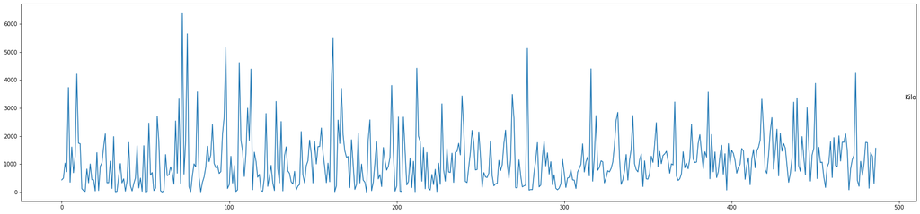

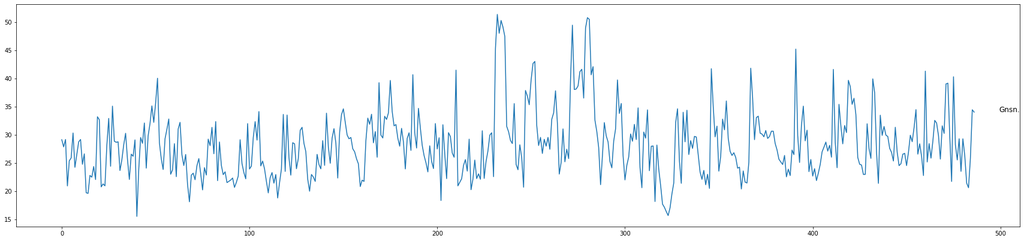

```python
dataset = df.copy()
values = df.values
groups = [1,2]
i = 1

pyplot.figure()
for group in groups:
	plt.figure(figsize=(30,15))
	pyplot.subplot(len(groups), 1, i)
	pyplot.plot(values[:, group])
	pyplot.title(dataset.columns[group], y=0.5, loc='right')
	i += 1
pyplot.show()
```

## Udarbejdelse af forudsigelsesmodellen

Med udgangspunkt i Torks i sortering 4 vil dette afsnit udarbejde en forudsigelsesmodel. FBProphet er den valgte model som vil blive anvendt.

```python
df
```

|  | Dato | Kilo | Gnsn. |
| --- | --- | --- | --- |
| 0 | 2019-01-02 | 439.00 | 29.17 |
| 1 | 2019-01-03 | 502.33 | 27.90 |
| 2 | 2019-01-04 | 1040.33 | 29.21 |
| 3 | 2019-01-05 | 729.00 | 20.97 |
| 4 | 2019-01-07 | 3736.00 | 25.42 |
| ... | ... | ... | ... |
| 482 | 2020-12-14 | 141.00 | 21.48 |
| 483 | 2020-12-15 | 1411.00 | 20.65 |
| 484 | 2020-12-16 | 1281.00 | 25.87 |
| 485 | 2020-12-17 | 316.00 | 34.48 |
| 486 | 2020-12-18 | 1570.50 | 34.07 |

487 rows × 3 columns

```python
prophet = df.copy()
```

```python
prophet.info()
```

```
<class 'pandas.core.frame.DataFrame'>
Int64Index: 487 entries, 0 to 486
Data columns (total 3 columns):
 #   Column  Non-Null Count  Dtype
---  ------  --------------  -----
 0   Dato    487 non-null    datetime64[ns]
 1   Kilo    487 non-null    float64
 2   Gnsn.   487 non-null    float64
dtypes: datetime64[ns](1), float64(2)
memory usage: 15.2 KB
```

```python
prophet.columns = ['ds', 'Kilo', 'y']
prophet
```

|  | ds | Kilo | y |
| --- | --- | --- | --- |
| 0 | 2019-01-02 | 439.00 | 29.17 |
| 1 | 2019-01-03 | 502.33 | 27.90 |
| 2 | 2019-01-04 | 1040.33 | 29.21 |
| 3 | 2019-01-05 | 729.00 | 20.97 |
| 4 | 2019-01-07 | 3736.00 | 25.42 |
| ... | ... | ... | ... |
| 482 | 2020-12-14 | 141.00 | 21.48 |
| 483 | 2020-12-15 | 1411.00 | 20.65 |
| 484 | 2020-12-16 | 1281.00 | 25.87 |
| 485 | 2020-12-17 | 316.00 | 34.48 |
| 486 | 2020-12-18 | 1570.50 | 34.07 |

487 rows × 3 columns

FBProphet har den mulighed at man kan fjerne weekender og dermed undgå støj. Dette gøres nedenfor.

```python
prophet.set_index('ds', inplace=True)
prophet = prophet[prophet.index.dayofweek < 5].reset_index()

fig = go.Figure()

fig.add_trace(go.Scatter(x=prophet['ds'], y=prophet['y'], name='Gnsn.',))
fig.show()
```

[interactive chart not shown]

For at anvende dataene i analysen skal de først tranformeres til en normalfordeling med box cox værktøjet.

```python
prophet['y'], lam = boxcox(prophet['y'])
print('Lambda is:', lam)
```

```
Lambda is: -0.5732127070330892
```

Baselinemodel

```python
m = Prophet()

m.fit(prophet)

future = m.make_future_dataframe(periods=0, freq='D')
forecast = m.predict(future)
print(forecast[['ds', 'yhat', 'yhat_lower', 'yhat_upper']])
```

```
INFO:fbprophet:Disabling yearly seasonality. Run prophet with yearly_seasonality=True to override this.
INFO:fbprophet:Disabling daily seasonality. Run prophet with daily_seasonality=True to override this.
```

```
            ds      yhat  yhat_lower  yhat_upper
0   2019-01-02  1.474768    1.443725    1.512695
1   2019-01-03  1.478218    1.445122    1.515691
2   2019-01-04  1.475191    1.440794    1.511442
3   2019-01-07  1.476700    1.441222    1.509715
4   2019-01-08  1.470949    1.436394    1.508379
..         ...       ...         ...         ...
426 2020-12-14  1.494532    1.459003    1.530816
427 2020-12-15  1.488896    1.452986    1.525176
428 2020-12-16  1.492579    1.456901    1.526631
429 2020-12-17  1.496145    1.460446    1.531418
430 2020-12-18  1.493234    1.456521    1.526639

[431 rows x 4 columns]
```

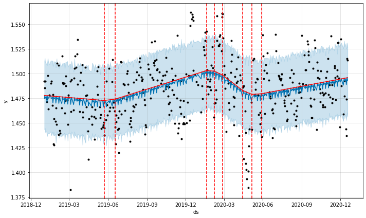

```python
fig = m.plot(forecast)
a = add_changepoints_to_plot(fig.gca(), m, forecast)
```

```python
m = Prophet()
m.fit(prophet)
future = m.make_future_dataframe(periods=0, freq='D')
future = future.merge(prophet, on='ds')
forecast = m.predict(future)
```

```
INFO:fbprophet:Disabling yearly seasonality. Run prophet with yearly_seasonality=True to override this.
INFO:fbprophet:Disabling daily seasonality. Run prophet with daily_seasonality=True to override this.
```

```python
cross_validation_results = cross_validation(m, horizon='100 days')
```

```
INFO:fbprophet:Making 7 forecasts with cutoffs between 2019-11-14 00:00:00 and 2020-09-09 00:00:00
```

```python
performance_metrics_results = performance_metrics(cross_validation_results)
performance_metrics_results['rmse'].head(1)
```

```
0    0.036769
Name: rmse, dtype: float64
```

Model med ekstra regressor

```python
m = Prophet()
m.add_regressor('Kilo', standardize=False)

m.fit(prophet)
future = m.make_future_dataframe(periods=0, freq='D')
future = future.merge(prophet, on='ds')
forecast = m.predict(future)
fig = go.Figure()

fig.add_trace(go.Scatter(x=prophet['ds'], y=prophet['y'], name='Actual',))
fig.add_trace(go.Scatter(x=forecast['ds'], y=forecast['yhat'], name='Predicted',))
fig.show()
```

```
INFO:fbprophet:Disabling yearly seasonality. Run prophet with yearly_seasonality=True to override this.
INFO:fbprophet:Disabling daily seasonality. Run prophet with daily_seasonality=True to override this.
```

[interactive chart not shown]

```python
cross_validation_results = cross_validation(m, horizon='100 days')
```

```
INFO:fbprophet:Making 7 forecasts with cutoffs between 2019-11-14 00:00:00 and 2020-09-09 00:00:00
```

```
WARNING:fbprophet.models:Optimization terminated abnormally. Falling back to Newton.
```

```python
performance_metrics_results = performance_metrics(cross_validation_results)
performance_metrics_results['rmse'].head(1)
```

```
0    0.028822
Name: rmse, dtype: float64
```

For at optimere modellen anvendes gridsearch til at forbedre de enkelte parametre.

De forskellige parametre som er afprøvet er:

'changepoint_prior_scale': [0.01, 0.05, 0.1, 0.25, 0.5],

'yearly_seasonality':[5, 10, 15, 20],

'weekly_seasonality':[5, 10, 15, 20],

```python
def create_param_combinations(**param_dict):
    param_iter = itertools.product(*param_dict.values())
    params =[]
    for param in param_iter:
        params.append(param)
    params_df = pd.DataFrame(params, columns=list(param_dict.keys()))
    return params_df

def single_cv_run(history_df, metrics, param_dict, parallel):
    m = Prophet(**param_dict)
    m.add_regressor('Kilo', standardize=False)
    m.fit(history_df)
    df_cv = cross_validation(m, horizon='100 days')
    df_p = performance_metrics(df_cv, rolling_window=1)
    df_p['params'] = str(param_dict)
    df_p = df_p.loc[:, metrics]
    return df_p

# Oversigt over de forskellige parametre der er afprøvet:
#'changepoint_range': [0.6, 0.7, 0.75, 0.8, 0.9],
#'changepoint_prior_scale': [0.01, 0.05, 0.1, 0.25, 0.5],
#'seasonality_prior_scale':[0.5, 1.0, 2.5, 5],
#'yearly_seasonality':[5, 10, 15, 20],
#'weekly_seasonality':[5, 10, 15, 20],


pd.set_option('display.max_colwidth', None)
param_grid = {  'changepoint_range': [0.3],
                'changepoint_prior_scale': [0.01],
                'seasonality_prior_scale':[3],
                'yearly_seasonality':[20],
                'weekly_seasonality':[5],
              }
metrics = ['horizon', 'rmse', 'mae', 'mape', 'mdape','params']
results = []

#Prophet(,)
params_df = create_param_combinations(**param_grid)
for param in params_df.values:
    param_dict = dict(zip(params_df.keys(), param))
    cv_df = single_cv_run(prophet,  metrics, param_dict, parallel="processes")
    results.append(cv_df)
results_df = pd.concat(results).reset_index(drop=True)
best_param = results_df.loc[results_df['rmse'] == min(results_df['rmse']), ['params']]
print(f'\n The best param combination is {best_param.values[0][0]}')
```

```
INFO:fbprophet:Disabling daily seasonality. Run prophet with daily_seasonality=True to override this.
INFO:fbprophet:Making 6 forecasts with cutoffs between 2020-01-03 00:00:00 and 2020-09-09 00:00:00
```

```
WARNING:fbprophet.models:Optimization terminated abnormally. Falling back to Newton.
WARNING:fbprophet.models:Optimization terminated abnormally. Falling back to Newton.
```

```
 The best param combination is {'changepoint_range': 0.3, 'changepoint_prior_scale': 0.01, 'seasonality_prior_scale': 3.0, 'yearly_seasonality': 20.0, 'weekly_seasonality': 5.0}
```

```python
m = Prophet(changepoint_prior_scale=0.01,
            changepoint_range=0.3,
            seasonality_prior_scale=3,
            yearly_seasonality=5,
            weekly_seasonality=20,
            seasonality_mode='additive')
m.add_regressor('Kilo', standardize=False)

m.fit(prophet)
```

```
INFO:fbprophet:Disabling daily seasonality. Run prophet with daily_seasonality=True to override this.
```

```
<fbprophet.forecaster.Prophet at 0x7f86e42a8198>
```

```python
cross_validation_results = cross_validation(m, horizon='100 days')
```

```
INFO:fbprophet:Making 6 forecasts with cutoffs between 2020-01-03 00:00:00 and 2020-09-09 00:00:00
```

```
WARNING:fbprophet.models:Optimization terminated abnormally. Falling back to Newton.
```

```python
performance_metrics_results = performance_metrics(cross_validation_results)
performance_metrics_results['rmse'].head(0)
```

```
Series([], Name: rmse, dtype: float64)
```

```python
fig = go.Figure()
fig.add_trace(go.Scatter(x=prophet['ds'], y=prophet['y'], name='Actual',))
fig.add_trace(go.Scatter(x=forecast['ds'], y=forecast['yhat'], name='Prediction',))
fig.add_trace(go.Scatter(x=forecast['ds'], y=forecast['trend'], name='Trend',))

fig.show()
```

[interactive chart not shown]

```python
future = m.make_future_dataframe(periods=0, freq='D')
future = future.merge(prophet, on='ds')
forecast = m.predict(future)
```

Tilbagetransformering af 'y' variablen så vi kan få de aktuelle priser.

```python
forecast[['yhat','yhat_upper','yhat_lower']] = forecast[['yhat','yhat_upper','yhat_lower']].apply(lambda x: inv_boxcox(x, lam))
prophet['y'] = inv_boxcox(prophet['y'], lam)
```

```python
fig = go.Figure()
fig.add_trace(go.Scatter(x=prophet['ds'], y=prophet['y'], name='Actual',))
fig.add_trace(go.Scatter(x=forecast['ds'], y=forecast['yhat'], name='Predicted',))
fig.show()
```

[interactive chart not shown]

```python
future_dates = m.make_future_dataframe(periods=3)
```

Fremtidige tilførsler på fiskeauktionerne. Oplysningerne er trukket fra deres respektive hjemmesider fredag aften (dag 430 ifølge modellen)

```python
nye_kilo = pd.DataFrame([0, 0, 15100])
gamle_kilo = prophet['Kilo'].copy()
```

```python
Kilo = pd.concat([gamle_kilo, nye_kilo], ignore_index=True)
future_dates['Kilo'] = Kilo
```

```python
predictions = m.predict(future_dates)
predictions = predictions.iloc[430:]
```

```python
predictions[['yhat','yhat_upper','yhat_lower']] = predictions[['yhat','yhat_upper','yhat_lower']].apply(lambda x: inv_boxcox(x, lam))
prophet['y'] = inv_boxcox(prophet['y'], lam)
```

Dag 431 og 432 er weekend og kan derfor ikke anvendes. Dag 433 er den næste auktionsdag (den 21/12/2020)

```python
predictions['yhat'].tail(3)
```

```
431    41.562774
432    41.773220
433    21.588992
Name: yhat, dtype: float64
```

```python
fig = go.Figure()
fig.add_trace(go.Scatter(x=predictions['ds'], y=predictions['yhat'], name='Predicted',))

fig.show()
```

[interactive chart not shown]

Ifølge forudsigelsesmodellen vil den kommende mandags auktionspris dermed være på 21,6 kr pr kilo torsk i sortering 4.